# Arkas: RNA-Seq Analysis In Much Less Time

Anthony R. Colombo, Timothy Triche Jr., Harold Pimentel

12 July, 2016

```
## [1] "making /data/output/appresults/projID/sampleName"
## [1] "creating analysis output directories for twa, gwa, enrichment,and normalization data.."
```

# 1 Annotating Kallisto Experiment against ENSEMBL/RepBase

```
## Setting transcriptome automatically from Kallisto call string.
```

# 2 ERCC Analysis

If ERCC spike-ins are present in the samples, and if their counts are non-zero, Arkas-Analysis performs an analysis outputting FDR, ROC plots, and plots the FPR.vs.TPR for various ratio tests. If ERCC counts are non-detected, then Arkas-Analysis removes unwanted variance using in silico negative controls, and outputs a heatmap of normalized counts. Arkas provides raw expression counts and batch effect normalization where the users can decide which data set to be used in their analysis.

```
## For the time being, only summing of bundles is supported
```

```
## Did not detect a vector of in silico negative controls...
```

```
## Checking for a design matrix in metadata(kexp)...
```

```
## Found design matrix, determining in silico negative controls...
```

```
## performing gene-wise-analysis...
```

```
## Fitting bundles...
```

```
## For the time being, only summing of bundles is supported
```

```
## fitting using FDR: BH
```

```
## found 29181 DE genes using FDR procedure BH
```

```
## [1] "found 12152 with adj.P.Val greater than 0.55 used as negative in silico controls "
```

```
## For the time being, only summing of bundles is supported
```

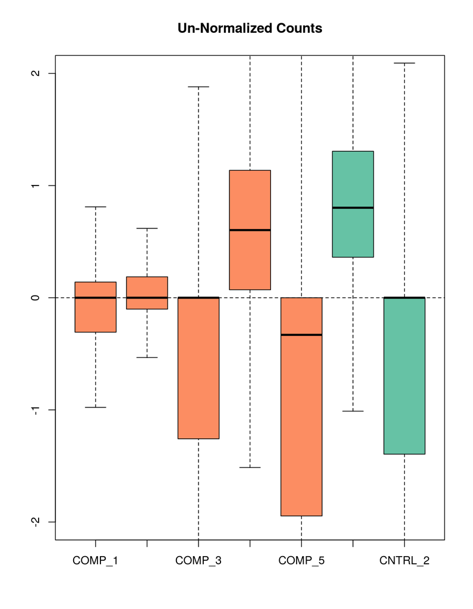

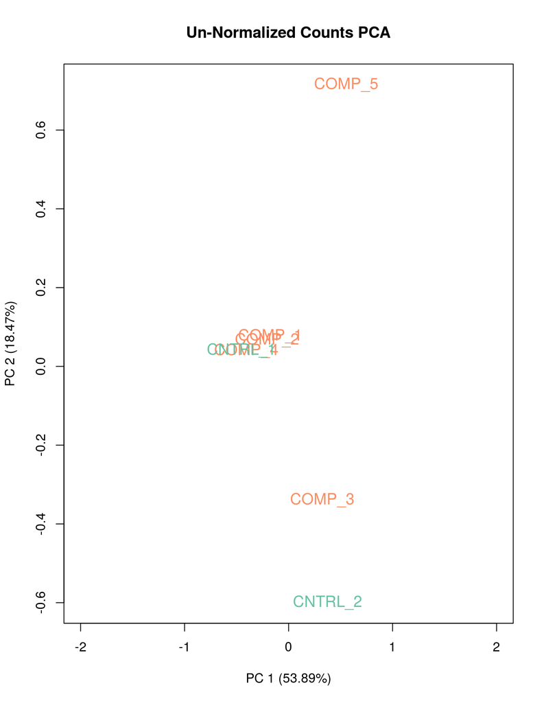

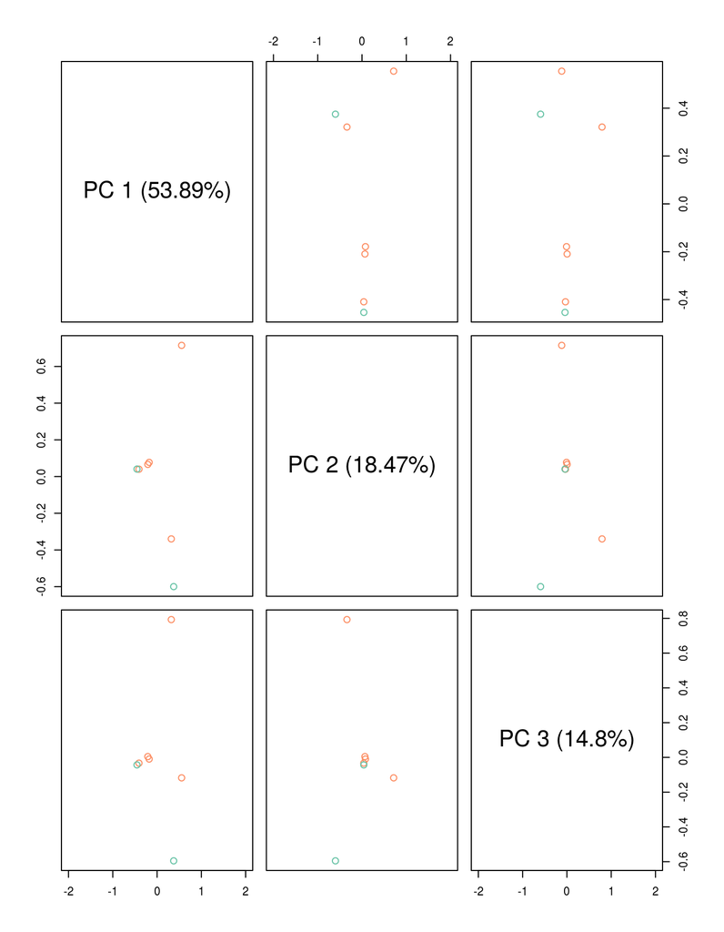

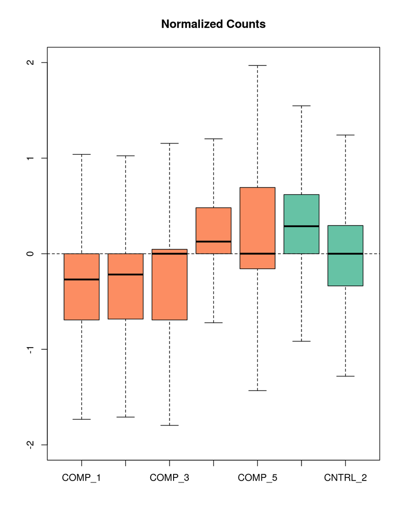

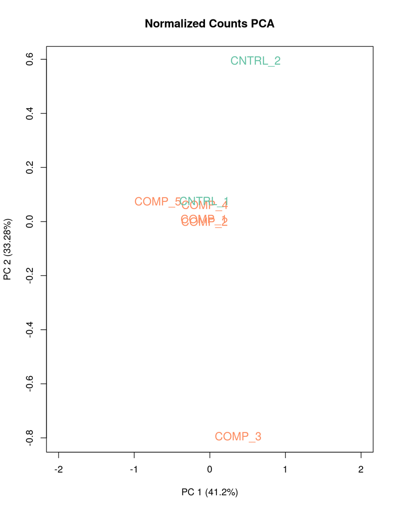

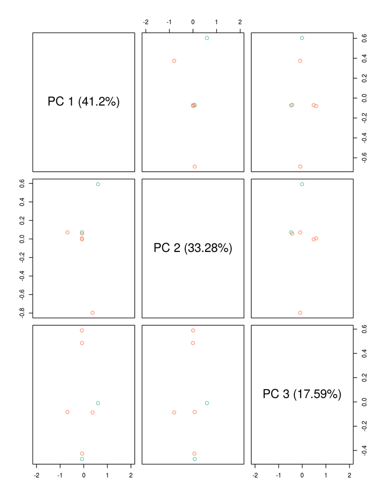

# 3 Gene Level Analysis UnNormalized

Gene Wise analysis is ran on two designs, first without model the removal of unwanted variance factors, and the other with the weights correcting unwanted variance by RUVSeq.

```
## Fitting bundles...
```

```
## For the time being, only summing of bundles is supported
```

```
## fitting using FDR: BH
```

```
## fitting using FDR: none
```

```
## found 625 DE genes using FDR procedure none
```

```
## finding entrez IDs of top ensembl genes...
```

Top 40 Diff.Expressed Genes

|  | logFC | AveExpr | t | adj.P.Val | B | Gene.symbol | Gene.title |
| --- | --- | --- | --- | --- | --- | --- | --- |
| ENSMUSG00000021127 | 0.3870139 | 10.269300 | 44.764978 | 0.0000000 | 12.4765534 | Zfp36l1 | zinc finger protein 36, C3H type-like 1 [Source:MGI Symbol;Acc:MGI:107946] |
| ENSMUSG00000043716 | 0.2439893 | 9.810902 | 23.128007 | 0.0000000 | 8.2770781 | Rpl7 | ribosomal protein L7 [Source:MGI Symbol;Acc:MGI:98073] |
| ENSMUSG00000086583 | 0.2446008 | 9.853825 | 12.856148 | 0.0000012 | 3.3122105 | Gm15500 | predicted pseudogene 15500 [Source:MGI Symbol;Acc:MGI:3782947] |
| ENSMUSG00000062825 | 0.4480001 | 10.703923 | 9.173980 | 0.0000155 | 0.3150673 | Actg1 | actin, gamma, cytoplasmic 1 [Source:MGI Symbol;Acc:MGI:87906] |
| ENSMUSG00000029580 | 1.0629081 | 10.417678 | 8.413334 | 0.0000292 | 0.2012611 | Actb | actin, beta [Source:MGI Symbol;Acc:MGI:87904] |
| ENSMUSG00000020681 | -1.5483430 | 6.662799 | -8.411556 | 0.0000293 | 0.8950138 | Ace | angiotensin I converting enzyme (peptidyl-dipeptidase A) 1 [Source:MGI Symbol;Acc:MGI:87874] |
| ENSMUSG00000032216 | -0.1405320 | 10.306861 | -8.012855 | 0.0000417 | 0.0989687 | Nedd4 | neural precursor cell expressed, developmentally down-regulated 4 [Source:MGI Symbol;Acc:MGI:97297] |
| ENSMUSG00000053113 | 0.1747823 | 10.383245 | 7.706480 | 0.0000552 | -1.7392014 | Socs3 | suppressor of cytokine signaling 3 [Source:MGI Symbol;Acc:MGI:1201791] |
| ENSMUSG00000069833 | 0.1857604 | 9.720774 | 7.525450 | 0.0000655 | -1.0582183 | Ahnak | AHNAK nucleoprotein (desmoyokin) [Source:MGI Symbol;Acc:MGI:1316648] |
| ENSMUSG00000020372 | 0.2548687 | 9.944593 | 6.999217 | 0.0001094 | -1.2818834 | Gnb2l1 | guanine nucleotide binding protein (G protein), beta polypeptide 2 like 1 [Source:MGI Symbol;Acc:MGI:101849] |
| ENSMUSG00000026478 | -0.2544714 | 9.973959 | -6.824391 | 0.0001306 | -1.1990198 | Lamc1 | laminin, gamma 1 [Source:MGI Symbol;Acc:MGI:99914] |
| ENSMUSG00000030744 | 0.2545028 | 9.674136 | 6.708837 | 0.0001471 | -1.2189088 | Rps3 | ribosomal protein S3 [Source:MGI Symbol;Acc:MGI:1350917] |
| ENSMUSG00000037813 | -1.9048540 | 5.255549 | -6.372460 | 0.0002098 | -2.0920146 | D630003M21Rik | RIKEN cDNA D630003M21 gene [Source:MGI Symbol;Acc:MGI:3606579] |
| ENSMUSG00000000787 | 0.2533395 | 9.671729 | 6.150465 | 0.0002671 | -1.8035255 | Ddx3x | DEAD/H (Asp-Glu-Ala-Asp/His) box polypeptide 3, X-linked [Source:MGI Symbol;Acc:MGI:103064] |
| ENSMUSG00000094388 | -9.9953503 | -2.298394 | -6.138344 | 0.0002707 | -4.0500562 | Gm8783 | predicted pseudogene 8783 [Source:MGI Symbol;Acc:MGI:3646027] |
| ENSMUSG00000096592 | -9.9953503 | -2.298394 | -6.138344 | 0.0002707 | -4.0500562 | Gm15801 | predicted gene 15801 [Source:MGI Symbol;Acc:MGI:3779625] |
| ENSMUSG00000040488 | -0.4832741 | 9.911662 | -5.824912 | 0.0003848 | -1.9485579 | Ltbp4 | latent transforming growth factor beta binding protein 4 [Source:MGI Symbol;Acc:MGI:1321395] |
| ENSMUSG00000022884 | 0.1419349 | 9.440105 | 5.590601 | 0.0005047 | -1.7753838 | Eif4a2 | eukaryotic translation initiation factor 4A2 [Source:MGI Symbol;Acc:MGI:106906] |
| ENSMUSG00000082016 | -9.1322647 | -2.837006 | -5.560250 | 0.0005230 | -4.1163057 | Pgam1-ps2 | phosphoglycerate mutase 1, pseudogene 2 [Source:MGI Symbol;Acc:MGI:3645709] |
| ENSMUSG00000083240 | -7.8782698 | -4.962476 | -5.538251 | 0.0005368 | -4.3225647 | Gm13453 | predicted gene 13453 [Source:MGI Symbol;Acc:MGI:3651618] |
| ENSMUSG00000020591 | -8.5489540 | -3.427085 | -5.262895 | 0.0007467 | -4.2355802 | Ntsr2 | neurotensin receptor 2 [Source:MGI Symbol;Acc:MGI:108018] |
| ENSMUSG00000002985 | -1.3242690 | 9.546906 | -5.236729 | 0.0007709 | -1.4625980 | Apoe | apolipoprotein E [Source:MGI Symbol;Acc:MGI:88057] |
| ENSMUSG00000026208 | 0.2806536 | 9.271893 | 5.087249 | 0.0009268 | -1.8624478 | Des | desmin [Source:MGI Symbol;Acc:MGI:94885] |
| ENSMUSG00000047330 | 1.7316970 | 6.964008 | 4.895402 | 0.0011795 | -1.7400453 | Kcne4 | potassium voltage-gated channel, Isk-related subfamily, gene 4 [Source:MGI Symbol;Acc:MGI:1891125] |
| ENSMUSG00000038146 | -0.6456179 | 10.754333 | -4.809762 | 0.0013157 | -3.4288573 | Notch3 | notch 3 [Source:MGI Symbol;Acc:MGI:99460] |
| ENSMUSG00000044533 | 0.2307399 | 9.744700 | 4.764248 | 0.0013950 | -4.0205779 | Rps2 | ribosomal protein S2 [Source:MGI Symbol;Acc:MGI:105110] |
| ENSMUSG00000017009 | 0.8026297 | 10.165168 | 4.739176 | 0.0014409 | -3.7684614 | Sdc4 | syndecan 4 [Source:MGI Symbol;Acc:MGI:1349164] |
| ENSMUSG00000066491 | 6.6116462 | -3.301764 | 4.642132 | 0.0016346 | -4.3817846 | Gm6265 | predicted pseudogene 6265 [Source:MGI Symbol;Acc:MGI:3649160] |
| ENSMUSG00000027470 | -1.7876738 | 5.002914 | -4.629714 | 0.0016614 | -2.8204071 | Mylk2 | myosin, light polypeptide kinase 2, skeletal muscle [Source:MGI Symbol;Acc:MGI:2139434] |
| ENSMUSG00000060036 | 0.3560658 | 9.323458 | 4.624129 | 0.0016736 | -2.2567940 | Rpl3 | ribosomal protein L3 [Source:MGI Symbol;Acc:MGI:1351605] |
| ENSMUSG00000073737 | 5.2886214 | -3.766618 | 4.582071 | 0.0017686 | -4.3839532 | Gm10566 | predicted gene 10566 [Source:MGI Symbol;Acc:MGI:3642220] |
| ENSMUSG00000056487 | -8.2067119 | -3.326945 | -4.547238 | 0.0018517 | -4.2782230 | Mettl7a2 | methyltransferase like 7A2 [Source:MGI Symbol;Acc:MGI:3026615] |
| ENSMUSG00000098934 | 7.2479538 | -2.883185 | 4.492991 | 0.0019897 | -4.3778780 | Gm18853 | predicted gene, 18853 [Source:MGI Symbol;Acc:MGI:5011038] |
| ENSMUSG00000002265 | 0.5242933 | 9.677264 | 4.461497 | 0.0020749 | -3.6420174 | Peg3 | paternally expressed 3 [Source:MGI Symbol;Acc:MGI:104748] |
| ENSMUSG00000017466 | -0.2306180 | 9.310113 | -4.412109 | 0.0022166 | -2.8642072 | Timp2 | tissue inhibitor of metalloproteinase 2 [Source:MGI Symbol;Acc:MGI:98753] |
| ENSMUSG00000100750 | 0.6966202 | 7.342130 | 4.374453 | 0.0023316 | -1.2431356 | Gm29084 | predicted gene 29084 [Source:MGI Symbol;Acc:MGI:5579790] |
| ENSMUSG00000074903 | -6.4601628 | -5.502023 | -4.327622 | 0.0024838 | -4.4768904 | Gm2058 | predicted gene 2058 [Source:MGI Symbol;Acc:MGI:3805010] |
| ENSMUSG00000095136 | 3.5937152 | -5.521885 | 4.286693 | 0.0026255 | -4.2580239 | Gm12616 | predicted gene 12616 [Source:MGI Symbol;Acc:MGI:3649883] |
| ENSMUSG00000095605 | 3.5937152 | -5.521885 | 4.286693 | 0.0026255 | -4.2580239 | Gm12624 | predicted gene 12624 [Source:MGI Symbol;Acc:MGI:3650565] |
| ENSMUSG00000096088 | 3.5937152 | -5.521885 | 4.286693 | 0.0026255 | -4.2580239 | Gm12614 | predicted gene 12614 [Source:MGI Symbol;Acc:MGI:3649885] |

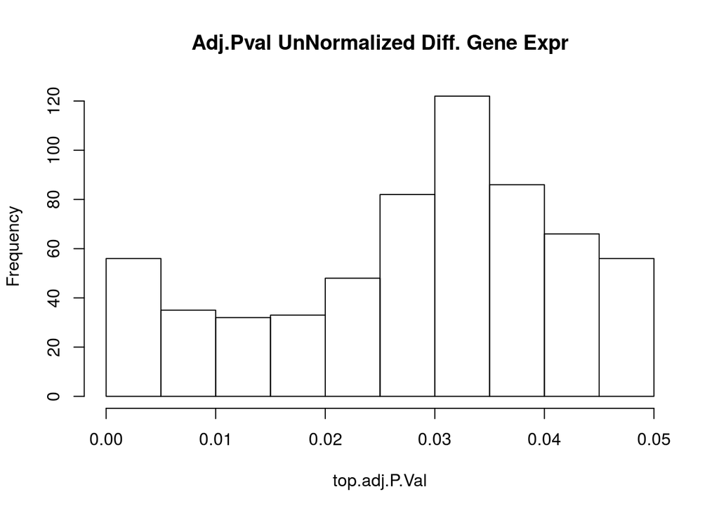

[output not shown]

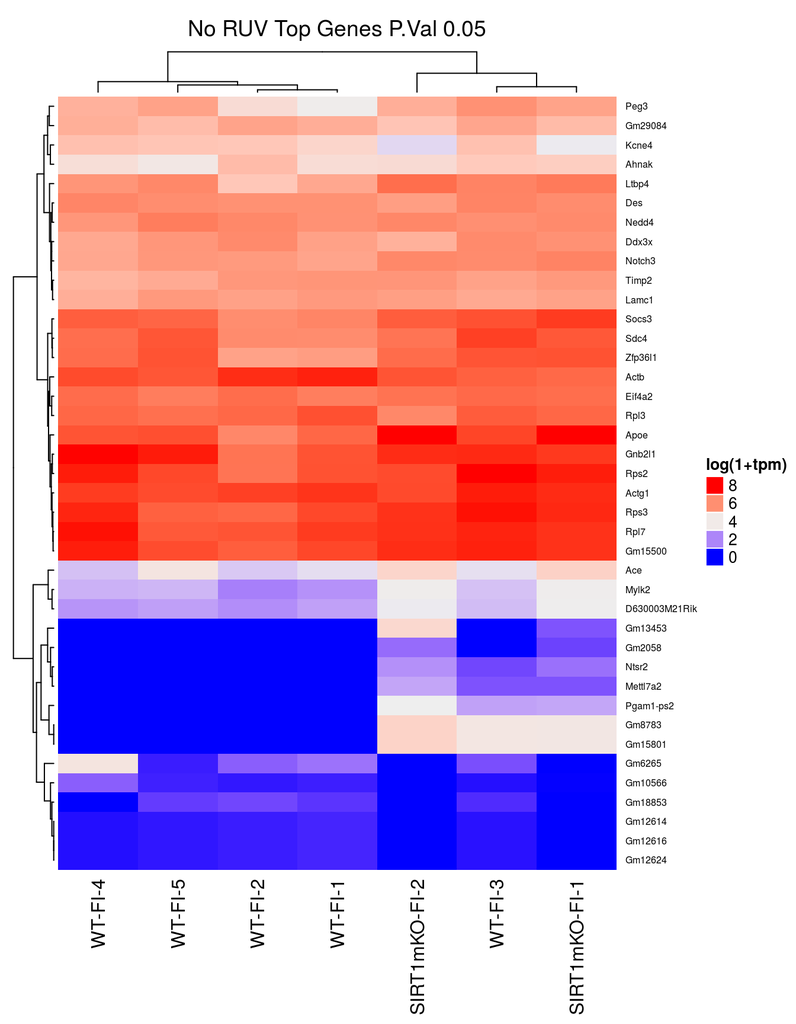

# 4 Gene Level Analysis Including Removal of UnWanted Variance

Here Arkas-Analysis models the gene expression count correction the unwanted factors.  
Comparing Gene counts with removal of unwanted variance can help detect batch effects. By default Arkas uses FDR procedure Benjami-Hochberg and discards genes that have less than 1 CPM across all samples.

```
## Fitting bundles...
```

```
## For the time being, only summing of bundles is supported
```

```
## fitting using FDR: BH
```

```
## fitting using FDR: none
```

```
## found 951 DE genes using FDR procedure none
```

```
## finding entrez IDs of top ensembl genes...
```

Top RUV Diff. Expr. Genes

|  | logFC | AveExpr | t | adj.P.Val | B | Gene.symbol | Gene.title |
| --- | --- | --- | --- | --- | --- | --- | --- |
| ENSMUSG00000023034 | 0.2250290 | 11.083787 | 25.789489 | 0.0000000 | 6.9666546 | Nr4a1 | nuclear receptor subfamily 4, group A, member 1 [Source:MGI Symbol;Acc:MGI:1352454] |
| ENSMUSG00000062825 | 0.2077356 | 10.703923 | 23.481799 | 0.0000000 | 7.9077380 | Actg1 | actin, gamma, cytoplasmic 1 [Source:MGI Symbol;Acc:MGI:87906] |
| ENSMUSG00000026185 | -0.5567329 | 11.066760 | -19.499258 | 0.0000001 | 5.7913872 | Igfbp5 | insulin-like growth factor binding protein 5 [Source:MGI Symbol;Acc:MGI:96440] |
| ENSMUSG00000020719 | 0.1525149 | 11.024551 | 18.800772 | 0.0000002 | 5.4180021 | Ddx5 | DEAD (Asp-Glu-Ala-Asp) box polypeptide 5 [Source:MGI Symbol;Acc:MGI:105037] |
| ENSMUSG00000064358 | 0.3644097 | 12.507630 | 13.111095 | 0.0000023 | 2.1998479 | mt-Co3 | mitochondrially encoded cytochrome c oxidase III [Source:MGI Symbol;Acc:MGI:102502] |
| ENSMUSG00000031502 | -0.1536067 | 10.701049 | -7.807017 | 0.0000822 | -0.5852292 | Col4a1 | collagen, type IV, alpha 1 [Source:MGI Symbol;Acc:MGI:88454] |
| ENSMUSG00000026879 | -0.1864716 | 10.836220 | -7.783985 | 0.0000838 | -0.3053145 | Gsn | gelsolin [Source:MGI Symbol;Acc:MGI:95851] |
| ENSMUSG00000020681 | -1.5613739 | 6.662799 | -6.947201 | 0.0001769 | -2.0962583 | Ace | angiotensin I converting enzyme (peptidyl-dipeptidase A) 1 [Source:MGI Symbol;Acc:MGI:87874] |
| ENSMUSG00000083240 | -8.9251360 | -4.962476 | -6.639746 | 0.0002368 | -4.4683403 | Gm13453 | predicted gene 13453 [Source:MGI Symbol;Acc:MGI:3651618] |
| ENSMUSG00000026478 | -0.2395470 | 9.973959 | -6.218884 | 0.0003590 | 0.2673499 | Lamc1 | laminin, gamma 1 [Source:MGI Symbol;Acc:MGI:99914] |
| ENSMUSG00000096941 | 6.8912850 | -1.483954 | 6.183046 | 0.0003723 | -4.4586817 | Gm26720 | predicted gene, 26720 [Source:MGI Symbol;Acc:MGI:5477214] |
| ENSMUSG00000040249 | -0.4584368 | 9.843566 | -6.101388 | 0.0004047 | 0.1477560 | Lrp1 | low density lipoprotein receptor-related protein 1 [Source:MGI Symbol;Acc:MGI:96828] |
| ENSMUSG00000002985 | -1.1960238 | 9.546906 | -6.013849 | 0.0004430 | 0.4954915 | Apoe | apolipoprotein E [Source:MGI Symbol;Acc:MGI:88057] |
| ENSMUSG00000037813 | -1.9055212 | 5.255549 | -5.599759 | 0.0006879 | -3.5833447 | D630003M21Rik | RIKEN cDNA D630003M21 gene [Source:MGI Symbol;Acc:MGI:3606579] |
| ENSMUSG00000074903 | -6.6819486 | -5.502023 | -5.368132 | 0.0008885 | -4.5193968 | Gm2058 | predicted gene 2058 [Source:MGI Symbol;Acc:MGI:3805010] |
| ENSMUSG00000038146 | -0.2021938 | 10.754333 | -5.365701 | 0.0008909 | -2.4079477 | Notch3 | notch 3 [Source:MGI Symbol;Acc:MGI:99460] |
| ENSMUSG00000094388 | -9.1485853 | -2.298394 | -4.823332 | 0.0016690 | -4.3484117 | Gm8783 | predicted pseudogene 8783 [Source:MGI Symbol;Acc:MGI:3646027] |
| ENSMUSG00000096592 | -9.1485853 | -2.298394 | -4.823332 | 0.0016690 | -4.3484117 | Gm15801 | predicted gene 15801 [Source:MGI Symbol;Acc:MGI:3779625] |
| ENSMUSG00000082780 | 3.3368378 | -5.697353 | 4.795723 | 0.0017251 | -4.3948848 | Rps11-ps5 | ribosomal protein S11, pseudogene 5 [Source:MGI Symbol;Acc:MGI:3647437] |
| ENSMUSG00000073737 | 5.1594297 | -3.766618 | 4.787973 | 0.0017412 | -4.4536988 | Gm10566 | predicted gene 10566 [Source:MGI Symbol;Acc:MGI:3642220] |
| ENSMUSG00000058135 | -0.6797814 | 8.075547 | -4.782649 | 0.0017524 | -1.2423201 | Gstm1 | glutathione S-transferase, mu 1 [Source:MGI Symbol;Acc:MGI:95860] |
| ENSMUSG00000067276 | -1.1434328 | 6.901603 | -4.776647 | 0.0017650 | -2.4411937 | Capn6 | calpain 6 [Source:MGI Symbol;Acc:MGI:1100850] |
| ENSMUSG00000046618 | -0.5339141 | 9.148440 | -4.725912 | 0.0018764 | -0.8910151 | Olfml2a | olfactomedin-like 2A [Source:MGI Symbol;Acc:MGI:2444741] |
| ENSMUSG00000047330 | 1.7227163 | 6.964008 | 4.611248 | 0.0021576 | -3.3205581 | Kcne4 | potassium voltage-gated channel, Isk-related subfamily, gene 4 [Source:MGI Symbol;Acc:MGI:1891125] |
| ENSMUSG00000078377 | -7.2864137 | -2.201670 | -4.560176 | 0.0022975 | -4.4167682 | Gm4294 | predicted gene 4294 [Source:MGI Symbol;Acc:MGI:3782472] |
| ENSMUSG00000095136 | 3.6123373 | -5.521885 | 4.534037 | 0.0023730 | -4.4066930 | Gm12616 | predicted gene 12616 [Source:MGI Symbol;Acc:MGI:3649883] |
| ENSMUSG00000095605 | 3.6123373 | -5.521885 | 4.534037 | 0.0023730 | -4.4066930 | Gm12624 | predicted gene 12624 [Source:MGI Symbol;Acc:MGI:3650565] |
| ENSMUSG00000096088 | 3.6123373 | -5.521885 | 4.534037 | 0.0023730 | -4.4066930 | Gm12614 | predicted gene 12614 [Source:MGI Symbol;Acc:MGI:3649885] |
| ENSMUSG00000066491 | 6.6477056 | -3.301764 | 4.452053 | 0.0026277 | -4.4759063 | Gm6265 | predicted pseudogene 6265 [Source:MGI Symbol;Acc:MGI:3649160] |
| ENSMUSG00000100750 | 0.7195196 | 7.342130 | 4.376674 | 0.0028885 | -2.4745687 | Gm29084 | predicted gene 29084 [Source:MGI Symbol;Acc:MGI:5579790] |
| ENSMUSG00000018819 | -1.2172937 | 6.971669 | -4.369639 | 0.0029143 | -2.5324857 | Lsp1 | lymphocyte specific 1 [Source:MGI Symbol;Acc:MGI:96832] |
| ENSMUSG00000027864 | -1.0544852 | 8.058356 | -4.360344 | 0.0029487 | -1.5763047 | Ptgfrn | prostaglandin F2 receptor negative regulator [Source:MGI Symbol;Acc:MGI:1277114] |
| ENSMUSG00000080810 | 3.9168312 | -5.319582 | 4.342346 | 0.0030166 | -4.4179011 | Gm11737 | predicted gene 11737 [Source:MGI Symbol;Acc:MGI:3650525] |
| ENSMUSG00000102918 | -0.9619639 | 7.767202 | -4.307852 | 0.0031515 | -1.8224370 | Pcdhgc3 | protocadherin gamma subfamily C, 3 [Source:MGI Symbol;Acc:MGI:1935201] |
| ENSMUSG00000027470 | -1.8314529 | 5.002914 | -4.303575 | 0.0031687 | -3.8853129 | Mylk2 | myosin, light polypeptide kinase 2, skeletal muscle [Source:MGI Symbol;Acc:MGI:2139434] |
| ENSMUSG00000106081 | -6.1379299 | -5.659465 | -4.190829 | 0.0036608 | -4.5312811 |  |  |
| ENSMUSG00000032198 | -0.8053006 | 7.198308 | -4.163283 | 0.0037933 | -2.4580166 | Dock6 | dedicator of cytokinesis 6 [Source:MGI Symbol;Acc:MGI:1914789] |
| ENSMUSG00000020108 | -1.0752830 | 7.542322 | -4.136508 | 0.0039271 | -2.1216505 | Ddit4 | DNA-damage-inducible transcript 4 [Source:MGI Symbol;Acc:MGI:1921997] |
| ENSMUSG00000098934 | 7.3069808 | -2.883185 | 4.091436 | 0.0041641 | -4.4849050 | Gm18853 | predicted gene, 18853 [Source:MGI Symbol;Acc:MGI:5011038] |
| ENSMUSG00000035530 | 0.1361969 | 8.971625 | 4.084337 | 0.0042028 | -1.7107854 | Eif1 | eukaryotic translation initiation factor 1 [Source:MGI Symbol;Acc:MGI:105125] |

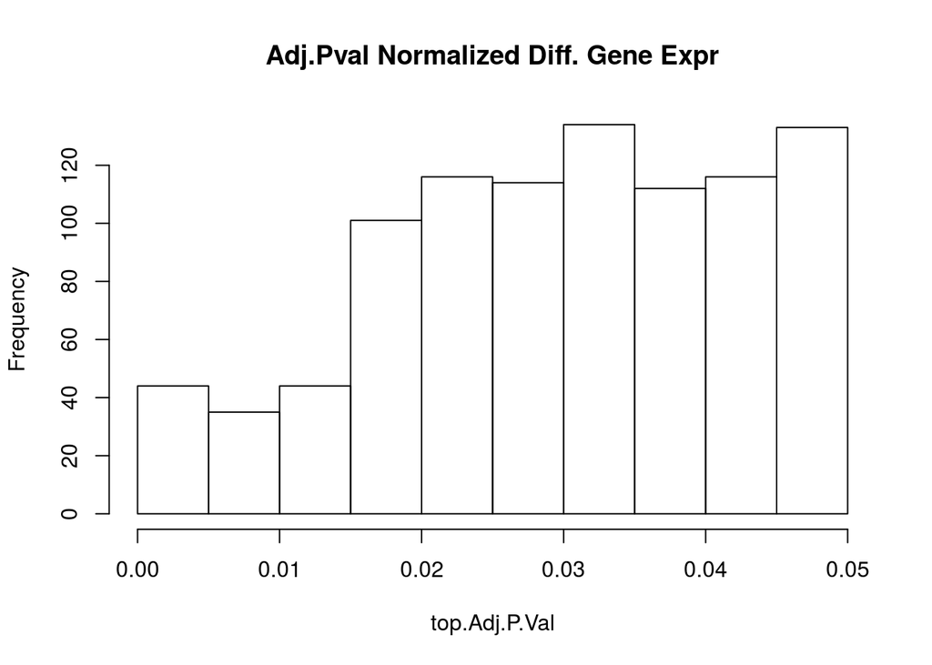

[output not shown]

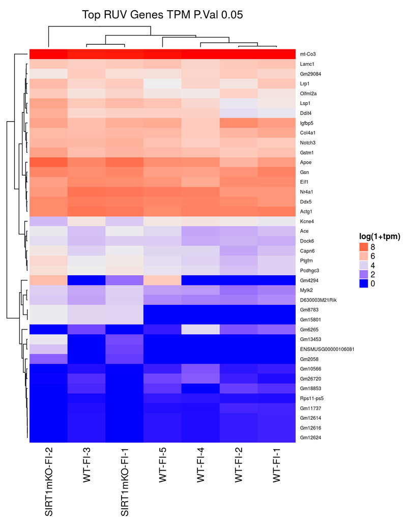

# 5 Repeat Level Analysis With Normalized Model

By default the FDR procedure is Benjami-Hochberg, and when collapsing repeats we discard any repeats that have less than 2 CPM across samples.

```
## It might be wise to run RUVg using ERCC controls prior to this...
```

```
## Fitting bundles...
```

```
## fitting using FDR: BH
```

```
## found 16 DE genes using FDR procedure BH
```

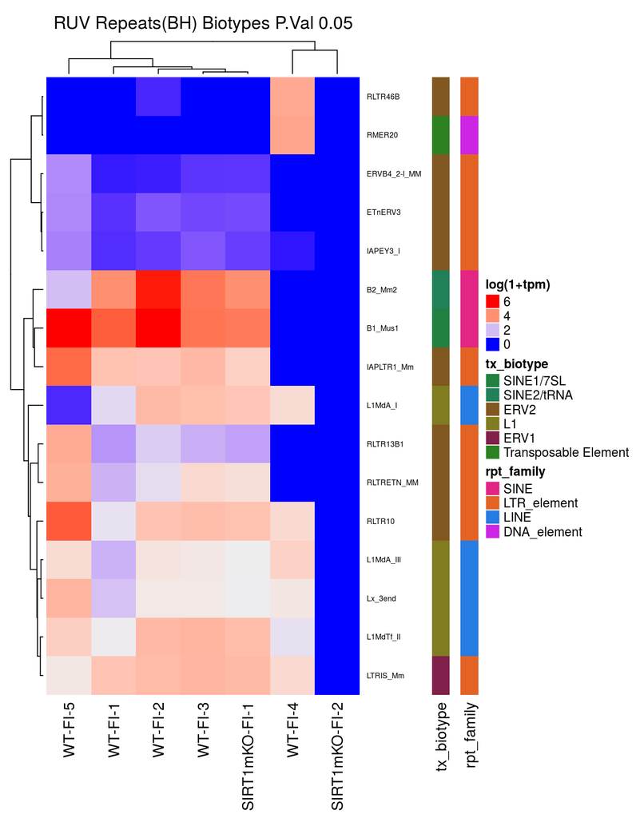

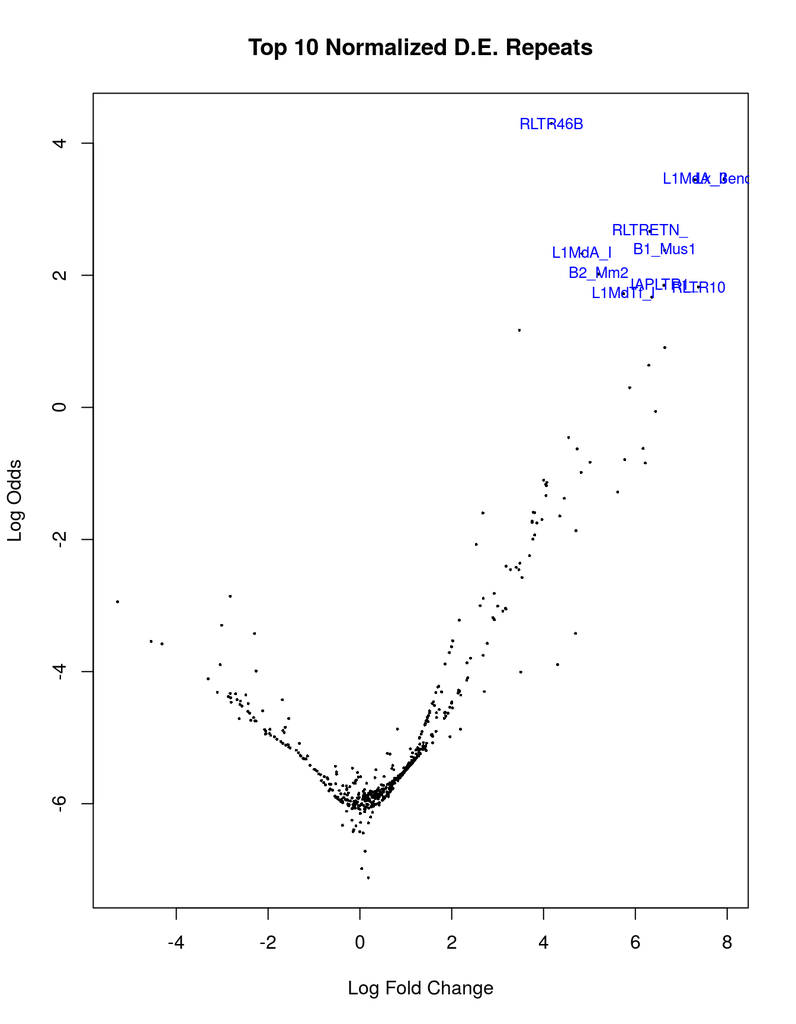

# 6 Repeat Level Analysis Without Removal of Un Wanted Variance Model

Here we plot the differential expression of detected repeats with a standard design matrix (no RUV). By default the FDR procedure is Benjami-Hochberg, and when collapsing repeats we discard any repeats that have less than 2 CPM across samples.

```
## It might be wise to run RUVg using ERCC controls prior to this...
```

```
## Fitting bundles...
```

```
## fitting using FDR: BH
```

```
## no DE found for using FDR: BH
```

```
## fitting using FDR: none
```

```
## found 41 DE genes using FDR procedure none
```

[output not shown]

[figure not shown]

# 7 Transcript Level Analysis UnNormalized Two-Group Comparison

Arkas Analysis output transcript level differential transcript expression of un-normalized data.

```
## Fitting bundles...
```

```
## It might be wise to run RUVg using ERCC controls prior to this...
```

```
## fitting using FDR: BH
```

```
## found 77 DE genes using FDR procedure BH
```

Top Diff. Expr Transcripts

|  | logFC | AveExpr | t | adj.P.Val | B | gene.name | gene.id |
| --- | --- | --- | --- | --- | --- | --- | --- |
| ENSMUST00000181751 | 1.358709 | 9.7373518 | 73.080918 | 0.0000000 | 30.1808445 | NA | ENSMUSG00000097554 |
| ENSMUST00000187117 | 1.847562 | 9.9036927 | 61.627804 | 0.0000000 | 26.9685050 | NA | ENSMUSG00000101249 |
| ENSMUST00000042105 | 1.041362 | 10.0241169 | 22.960018 | 0.0000001 | 14.4445957 | Ppp1r15a | ENSMUSG00000040435 |
| ENSMUST00000027997 | 1.545136 | 10.7068789 | 17.075312 | 0.0000013 | 10.4538898 | Rgs5 | ENSMUSG00000026678 |
| ENSMUST00000031668 | 2.702521 | 10.5105062 | 13.410577 | 0.0000206 | 7.2478099 | Col1a2 | ENSMUSG00000029661 |
| ENSMUST00000039631 | 3.149191 | 10.7688221 | 12.167502 | 0.0000582 | 7.3986463 | Acta2 | ENSMUSG00000035783 |
| ENSMUST00000142344 | -11.240124 | -3.2745186 | -10.795078 | 0.0002278 | 6.3098056 | Eif4g1 | ENSMUSG00000045983 |
| ENSMUST00000085636 | -10.880056 | -3.8680487 | -10.693682 | 0.0002445 | 5.8931255 | Gramd1a | ENSMUSG00000001248 |
| ENSMUST00000106491 | 11.047744 | -0.0359896 | 10.634606 | 0.0002509 | 4.4507258 | Cdc14a | ENSMUSG00000033502 |
| ENSMUST00000205328 | 10.929879 | -0.0506388 | 10.235413 | 0.0003811 | 4.4362881 | Grik5 | ENSMUSG00000003378 |
| ENSMUST00000005620 | 2.486739 | 10.0914372 | 10.073847 | 0.0004434 | 3.7760867 | Dnajb1 | ENSMUSG00000005483 |
| ENSMUST00000205340 | -10.806017 | -4.0494351 | -9.908708 | 0.0005201 | 5.2920739 | Sh2b1 | ENSMUSG00000030733 |
| ENSMUST00000107474 | 10.868442 | -0.0210644 | 8.957739 | 0.0014796 | 3.7830370 | Rara | ENSMUSG00000037992 |
| ENSMUST00000179422 | 10.642603 | -0.3567493 | 8.959188 | 0.0014796 | 3.3694023 | Ecsit | ENSMUSG00000066839 |
| ENSMUST00000168465 | 10.189732 | -0.4761022 | 7.912513 | 0.0055235 | 2.5427278 | Pcbp3 | ENSMUSG00000001120 |
| ENSMUST00000200955 | -9.601745 | -4.3307932 | -7.742252 | 0.0066501 | 1.8918345 | Atp8a1 | ENSMUSG00000037685 |
| ENSMUST00000164681 | 9.867961 | -0.9573278 | 7.697947 | 0.0068984 | 1.8370940 | Psmd13 | ENSMUSG00000025487 |
| ENSMUST00000168266 | 11.144213 | -0.1495289 | 7.652546 | 0.0071741 | 2.7028350 | Ssrp1 | ENSMUSG00000027067 |
| ENSMUST00000126972 | 9.810500 | -1.0239753 | 7.470561 | 0.0091057 | 1.6118905 | Trmt10b | ENSMUSG00000035601 |
| ENSMUST00000114445 | -9.849749 | -4.3586021 | -7.102197 | 0.0139825 | 2.2007674 | Cbx3 | ENSMUSG00000029836 |
| ENSMUST00000155452 | 10.190964 | -0.3789573 | 6.914924 | 0.0170701 | 1.9559144 | Atp5o | ENSMUSG00000022956 |
| ENSMUST00000021168 | 9.690848 | -1.1278350 | 6.931816 | 0.0170701 | 1.1402607 | Wscd1 | ENSMUSG00000020811 |
| ENSMUST00000146864 | 9.512993 | -1.1768488 | 6.916703 | 0.0170701 | 1.0704172 | Stx18 | ENSMUSG00000029125 |
| ENSMUST00000106845 | -10.390474 | -2.5191771 | -6.877999 | 0.0177042 | 1.8994956 | Hipk1 | ENSMUSG00000008730 |
| ENSMUST00000121931 | -10.298650 | -2.7814896 | -6.844936 | 0.0182635 | 2.1131186 | Clk2 | ENSMUSG00000068917 |
| ENSMUST00000198017 | 11.668918 | 1.2482121 | 6.807561 | 0.0189766 | 2.7091396 | Fscn1 | ENSMUSG00000029581 |
| ENSMUST00000134942 | 9.674391 | -0.7772752 | 6.754186 | 0.0202247 | 1.4236410 | Senp3 | ENSMUSG00000005204 |
| ENSMUST00000082407 | 1.446907 | 10.7549157 | 6.598362 | 0.0248695 | -1.0974617 | ATP8 | ENSMUSG00000064356 |
| ENSMUST00000112523 | 9.300087 | -0.8594517 | 6.581229 | 0.0250940 | 0.9143591 | Clstn3 | ENSMUSG00000008153 |
| ENSMUST00000163047 | -10.285765 | -2.4066459 | -6.515436 | 0.0273237 | 1.4350042 | Luc7l2 | ENSMUSG00000029823 |
| ENSMUST00000197539 | -11.245697 | -1.5679475 | -6.505259 | 0.0273237 | 1.2920088 | Ube2d3 | ENSMUSG00000078578 |
| ENSMUST00000202089 | -11.649658 | -1.2841244 | -6.471294 | 0.0283510 | 1.1923428 | Hsph1 | ENSMUSG00000029657 |
| ENSMUST00000205262 | 10.090040 | -0.4531757 | 6.428393 | 0.0288902 | 1.4732409 | Arhgap17 | ENSMUSG00000030766 |
| ENSMUST00000103159 | 9.458517 | -0.8514815 | 6.431202 | 0.0288902 | 1.0103072 | Kat7 | ENSMUSG00000038909 |
| ENSMUST00000138302 | -9.717537 | -3.0574404 | -6.409942 | 0.0292498 | 1.2663693 | Wbp1l | ENSMUSG00000047731 |
| ENSMUST00000020775 | -11.379750 | -1.5051237 | -6.391146 | 0.0292498 | 1.1341862 | Dynll2 | ENSMUSG00000020483 |
| ENSMUST00000020461 | -10.947747 | -1.2715669 | -6.305633 | 0.0325628 | 0.8849708 | Nfic | ENSMUSG00000055053 |
| ENSMUST00000170017 | 9.519364 | -1.1331615 | 6.260075 | 0.0345386 | 0.6615380 | Glod4 | ENSMUSG00000017286 |
| ENSMUST00000017077 | -10.219309 | -2.6802019 | -6.213951 | 0.0366864 | 1.4976818 | Plcg1 | ENSMUSG00000016933 |
| ENSMUST00000168631 | -9.503348 | -3.2593837 | -6.162731 | 0.0393136 | 0.9973296 | Pkp4 | ENSMUSG00000026991 |
| ENSMUST00000205800 | 9.366469 | -1.0996986 | 6.131164 | 0.0402486 | 0.5977659 | Gpi1 | ENSMUSG00000036427 |
| ENSMUST00000208744 | 9.084564 | -1.4231785 | 6.039228 | 0.0449905 | 0.1970058 | NA | ENSMUSG00000069755 |
| ENSMUST00000138841 | -9.020611 | -4.7049532 | -6.002313 | 0.0471518 | 0.1719592 | Stk3 | ENSMUSG00000022329 |
| ENSMUST00000168330 | 9.462071 | -0.8256695 | 5.972668 | 0.0488857 | 0.7359509 | Efemp2 | ENSMUSG00000024909 |

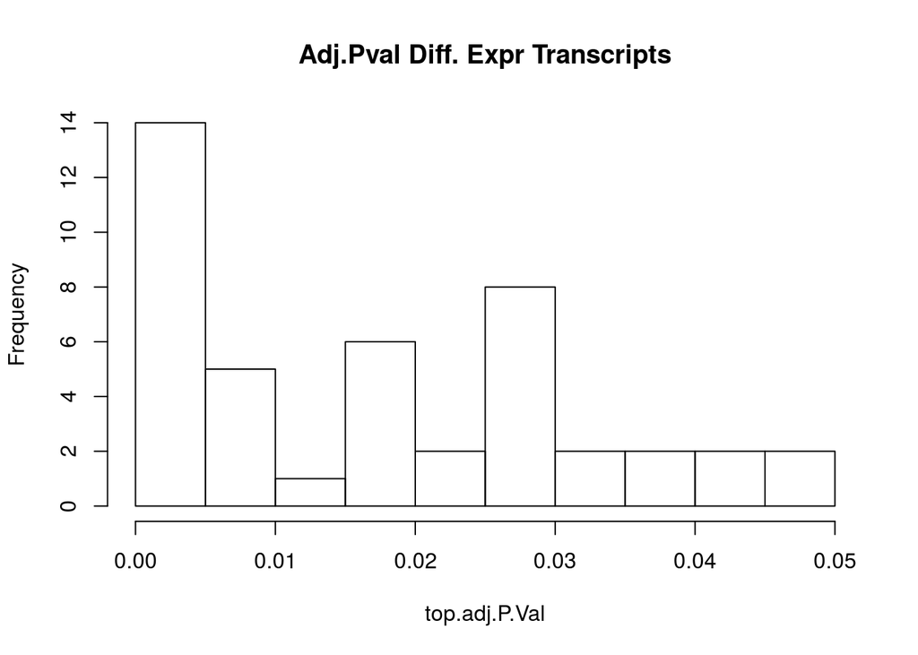

[output not shown]

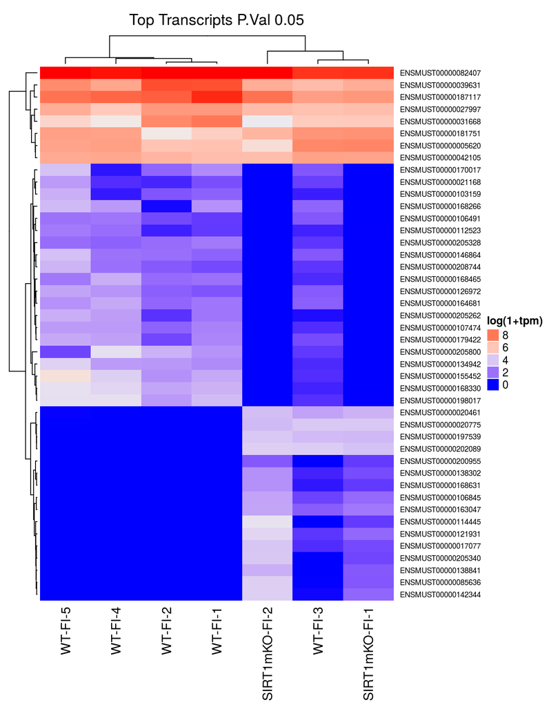

# 8 Transcript Level Analysis Including Corrections for UnWanted Variance

Arkas-Analysis performs transcrpit level analysis correcting for the factors of unwanted variance.

```
## Fitting bundles...
```

```
## It might be wise to run RUVg using ERCC controls prior to this...
```

```
## fitting using FDR: BH
```

```
## found 10 DE genes using FDR procedure BH
```

```
## Fitting bundles...
```

```
## It might be wise to run RUVg using ERCC controls prior to this...
```

```
## fitting using FDR: none
```

```
## found 3006 DE genes using FDR procedure none
```

Top RUV Diff. Expr Transcripts

|  | logFC | AveExpr | t | adj.P.Val | B | gene.name | gene.id |
| --- | --- | --- | --- | --- | --- | --- | --- |
| ENSMUST00000106491 | 11.148657 | -0.0359896 | 11.040599 | 0.0000013 | -1.7434043 | Cdc14a | ENSMUSG00000033502 |
| ENSMUST00000205328 | 11.060578 | -0.0506388 | 10.429902 | 0.0000022 | -1.6909696 | Grik5 | ENSMUSG00000003378 |
| ENSMUST00000085636 | -11.486357 | -3.8680487 | -10.416901 | 0.0000022 | -1.0877933 | Gramd1a | ENSMUSG00000001248 |
| ENSMUST00000205340 | -11.725578 | -4.0494351 | -10.258169 | 0.0000025 | -1.1836257 | Sh2b1 | ENSMUSG00000030733 |
| ENSMUST00000142344 | -11.410641 | -3.2745186 | -9.683376 | 0.0000041 | -0.8053027 | Eif4g1 | ENSMUSG00000045983 |
| ENSMUST00000179422 | 10.911278 | -0.3567493 | 9.480330 | 0.0000048 | -2.1114034 | Ecsit | ENSMUSG00000066839 |
| ENSMUST00000107474 | 11.212736 | -0.0210644 | 9.419575 | 0.0000051 | -1.9468156 | Rara | ENSMUSG00000037992 |
| ENSMUST00000164681 | 10.025997 | -0.9573278 | 8.723244 | 0.0000097 | -2.3845775 | Psmd13 | ENSMUSG00000025487 |
| ENSMUST00000126972 | 10.036714 | -1.0239753 | 8.551049 | 0.0000114 | -2.4929034 | Trmt10b | ENSMUSG00000035601 |
| ENSMUST00000200955 | -9.613410 | -4.3307932 | -8.323839 | 0.0000143 | -2.4395398 | Atp8a1 | ENSMUSG00000037685 |
| ENSMUST00000168465 | 10.495261 | -0.4761022 | 8.175949 | 0.0000165 | -2.2510422 | Pcbp3 | ENSMUSG00000001120 |
| ENSMUST00000146864 | 9.778874 | -1.1768488 | 7.942498 | 0.0000209 | -2.6097790 | Stx18 | ENSMUSG00000029125 |
| ENSMUST00000114445 | -11.160624 | -4.3586021 | -7.893467 | 0.0000220 | -2.1087160 | Cbx3 | ENSMUSG00000029836 |
| ENSMUST00000198017 | 12.085586 | 1.2482121 | 7.646792 | 0.0000284 | -1.8936746 | Fscn1 | ENSMUSG00000029581 |
| ENSMUST00000134942 | 10.215500 | -0.7772752 | 7.485909 | 0.0000337 | -2.5767173 | Senp3 | ENSMUSG00000005204 |
| ENSMUST00000155452 | 10.809818 | -0.3789573 | 7.455036 | 0.0000348 | -2.5634953 | Atp5o | ENSMUSG00000022956 |
| ENSMUST00000021168 | 9.881877 | -1.1278350 | 7.328855 | 0.0000399 | -2.6399402 | Wscd1 | ENSMUSG00000020811 |
| ENSMUST00000208744 | 9.501570 | -1.4231785 | 7.224357 | 0.0000447 | -2.8032167 | NA | ENSMUSG00000069755 |
| ENSMUST00000168266 | 11.355035 | -0.1495289 | 7.017556 | 0.0000563 | -2.4367181 | Ssrp1 | ENSMUSG00000027067 |
| ENSMUST00000205262 | 10.834340 | -0.4531757 | 6.902940 | 0.0000640 | -2.7160908 | Arhgap17 | ENSMUSG00000030766 |
| ENSMUST00000138841 | -9.517889 | -4.7049532 | -6.827238 | 0.0000698 | -2.8919563 | Stk3 | ENSMUSG00000022329 |
| ENSMUST00000112523 | 9.547494 | -0.8594517 | 6.814427 | 0.0000708 | -2.8351182 | Clstn3 | ENSMUSG00000008153 |
| ENSMUST00000131893 | 9.359319 | -1.4262998 | 6.790588 | 0.0000728 | -2.8332925 | Fbxo18 | ENSMUSG00000058594 |
| ENSMUST00000032570 | -9.958666 | -4.6538869 | -6.728826 | 0.0000781 | -2.8170297 | Dmwd | ENSMUSG00000030410 |
| ENSMUST00000168330 | 10.202484 | -0.8256695 | 6.724856 | 0.0000785 | -2.7433667 | Efemp2 | ENSMUSG00000024909 |
| ENSMUST00000031668 | 3.970870 | 10.5105062 | 6.670658 | 0.0000836 | -0.1458138 | Col1a2 | ENSMUSG00000029661 |
| ENSMUST00000085664 | 9.153508 | -0.4263145 | 6.663789 | 0.0000842 | -2.9561538 | Zfp433 | ENSMUSG00000096795 |
| ENSMUST00000159050 | -9.863878 | -4.6554683 | -6.554878 | 0.0000957 | -2.8815592 | Tle3 | ENSMUSG00000032280 |
| ENSMUST00000121491 | 9.098869 | -1.7184319 | 6.445531 | 0.0001088 | -2.9608663 | Ttpa | ENSMUSG00000073988 |
| ENSMUST00000115360 | 9.416633 | -1.5213820 | 6.411581 | 0.0001133 | -2.9681322 | Stau2 | ENSMUSG00000025920 |
| ENSMUST00000070487 | -9.287491 | -4.7947632 | -6.178559 | 0.0001502 | -3.1159809 | Cpsf4 | ENSMUSG00000029625 |
| ENSMUST00000111764 | -9.829280 | -4.7393256 | -6.114726 | 0.0001624 | -3.0422054 | Qsox1 | ENSMUSG00000033684 |
| ENSMUST00000170017 | 9.619811 | -1.1331615 | 6.093041 | 0.0001668 | -2.7807033 | Glod4 | ENSMUSG00000017286 |
| ENSMUST00000172695 | -9.939103 | -4.7304325 | -6.084714 | 0.0001685 | -3.0344932 | Pabpn1 | ENSMUSG00000022194 |
| ENSMUST00000103159 | 9.799549 | -0.8514815 | 6.079738 | 0.0001696 | -2.7447687 | Kat7 | ENSMUSG00000038909 |
| ENSMUST00000205800 | 9.506721 | -1.0996986 | 6.073429 | 0.0001709 | -2.7837806 | Gpi1 | ENSMUSG00000036427 |
| ENSMUST00000133039 | 8.706020 | -1.9508690 | 6.030563 | 0.0001802 | -3.0259322 | Trim47 | ENSMUSG00000020773 |
| ENSMUST00000125397 | 9.253668 | -1.6060227 | 5.979015 | 0.0001922 | -3.0356174 | Mrpl37 | ENSMUSG00000028622 |
| ENSMUST00000201420 | 9.076260 | -1.7323299 | 5.909748 | 0.0002096 | -3.0460230 | Pds5a | ENSMUSG00000029202 |
| ENSMUST00000202089 | -11.453273 | -1.2841244 | -5.907745 | 0.0002101 | -2.0560627 | Hsph1 | ENSMUSG00000029657 |
| ENSMUST00000020461 | -10.704220 | -1.2715669 | -5.841078 | 0.0002286 | -2.0167556 | Nfic | ENSMUSG00000055053 |
| ENSMUST00000082396 | 1.586982 | 11.3126416 | 5.757224 | 0.0002543 | -2.1687291 | ND2 | ENSMUSG00000064345 |
| ENSMUST00000204190 | 8.373929 | -2.1672330 | 5.712546 | 0.0002693 | -3.0995766 | Tmf1 | ENSMUSG00000030059 |
| ENSMUST00000020775 | -10.841236 | -1.5051237 | -5.671059 | 0.0002840 | -2.2478819 | Dynll2 | ENSMUSG00000020483 |
| ENSMUST00000196055 | -8.925503 | -4.2368344 | -5.620969 | 0.0003031 | -3.0429879 | Ap5z1 | ENSMUSG00000039623 |
| ENSMUST00000132294 | -9.392428 | -4.8508825 | -5.616978 | 0.0003046 | -3.2758854 | NA | ENSMUSG00000000031 |
| ENSMUST00000208839 | 7.556797 | -2.6792682 | 5.598841 | 0.0003119 | -3.0695315 | Insr | ENSMUSG00000005534 |
| ENSMUST00000197539 | -10.744578 | -1.5679475 | -5.566109 | 0.0003255 | -2.2033652 | Ube2d3 | ENSMUSG00000078578 |
| ENSMUST00000152276 | -8.341924 | -4.7322926 | -5.532140 | 0.0003402 | -3.3905256 | Rnf167 | ENSMUSG00000040746 |
| ERCC_vector | -6.720515 | 1.9834938 | -5.520855 | 0.0003453 | -2.7708402 | NA | ERCC_vector |

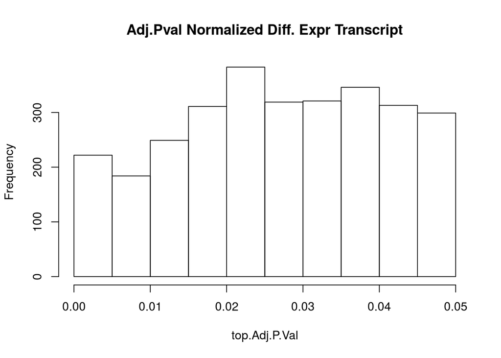

[output not shown]

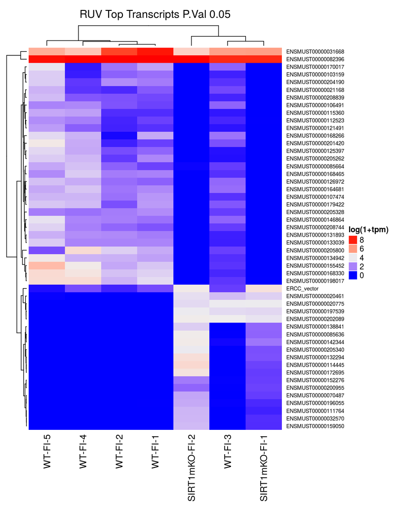

# 9 Enrichment Analysis

Enrichment is done using speedSage client package which accelerates Gene-Set Enrichment Analysis.Note that enrichment assumes that the variances between groups is not equal.

```
## [1] "Sample Group Variances"
```

```
## $CNTRL_1
## [1] 79.30134
##
## $COMP_0
## [1] 79.26697
```

```
## Aggregating gene data for gene sets.
## Low sample size detected. Increasing n.points in aggregateGeneSet.Done.
## Calculating variance inflation factors...Done.
```

Transcript Enrichment

| pathway.name | log.fold.change | p.Value | FDR |
| --- | --- | --- | --- |
| R-MMU-1912408 | -1.4012745 | 0.1665213 | 0.3330426 |
| R-MMU-5617472 | 0.3891199 | 0.7385132 | 0.7385132 |

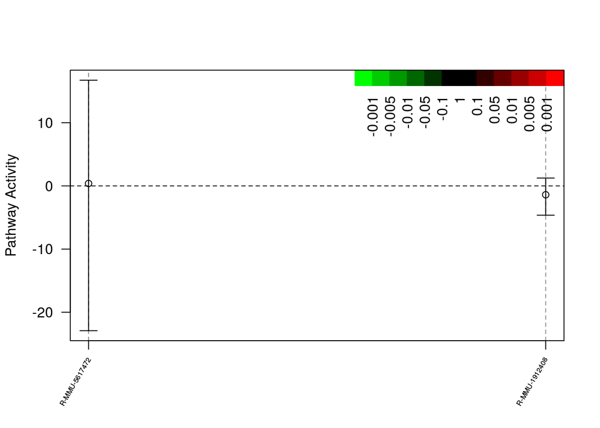

Full Enrichment Transcript Analysis

| pathway.name | log.fold.change | p.Value | FDR | tx.Url | Pathway.Description |
| --- | --- | --- | --- | --- | --- |
| R-MMU-1912408 | -1.4012745 | 0.1665213 | 0.3330426 | http://www.reactome.org/PathwayBrowser/#/R-MMU-1912408 | Pre-NOTCH Transcription and Translation |
| R-MMU-5617472 | 0.3891199 | 0.7385132 | 0.7385132 | http://www.reactome.org/PathwayBrowser/#/R-MMU-5617472 | Activation of anterior HOX genes in hindbrain development during early embryogenesis |

```
## [1] "printing out the reactome pathway transcript sets and associated gene names"
```

```
## named list()
```

# 10 Gene Level Enrichment

```
## [1] "Sample Group Variances"
```

```
## $CNTRL_1
## [1] 83.29326
##
## $COMP_0
## [1] 83.14527
```

```
## Aggregating gene data for gene sets.
## Low sample size detected. Increasing n.points in aggregateGeneSet...Done.
## Calculating variance inflation factors...Done.
```

Gene Enrichment Statistics

|  | pathway.name | log.fold.change | p.Value | FDR |
| --- | --- | --- | --- | --- |
| 3 | R-MMU-1368092 | -1.0133576 | 0.0798973 | 0.7845091 |
| 2 | R-MMU-1368082 | -1.1243012 | 0.1595532 | 0.7845091 |
| 6 | R-MMU-1912408 | -1.3858843 | 0.1681091 | 0.7845091 |
| 10 | R-MMU-2426168 | -0.6651033 | 0.2283595 | 0.7992584 |
| 13 | R-MMU-5667092 | -1.0970427 | 0.3993486 | 0.9418414 |
| 11 | R-MMU-400253 | -0.8906632 | 0.4036463 | 0.9418414 |
| 8 | R-MMU-2122947 | -0.3412004 | 0.7098422 | 0.9635735 |
| 7 | R-MMU-1989781 | 7.1152986 | 0.7223993 | 0.9635735 |
| 9 | R-MMU-2197563 | -0.5496997 | 0.8713630 | 0.9635735 |
| 12 | R-MMU-5617472 | 2.0429872 | 0.8893354 | 0.9635735 |
| 1 | R-MMU-1368071 | 1.2216964 | 0.8917126 | 0.9635735 |
| 14 | R-MMU-8851708 | 0.1778461 | 0.9239526 | 0.9635735 |
| 4 | R-MMU-1368108 | -0.5223108 | 0.9635735 | 0.9635735 |
| 5 | R-MMU-1368110 | -0.5223108 | 0.9635735 | 0.9635735 |

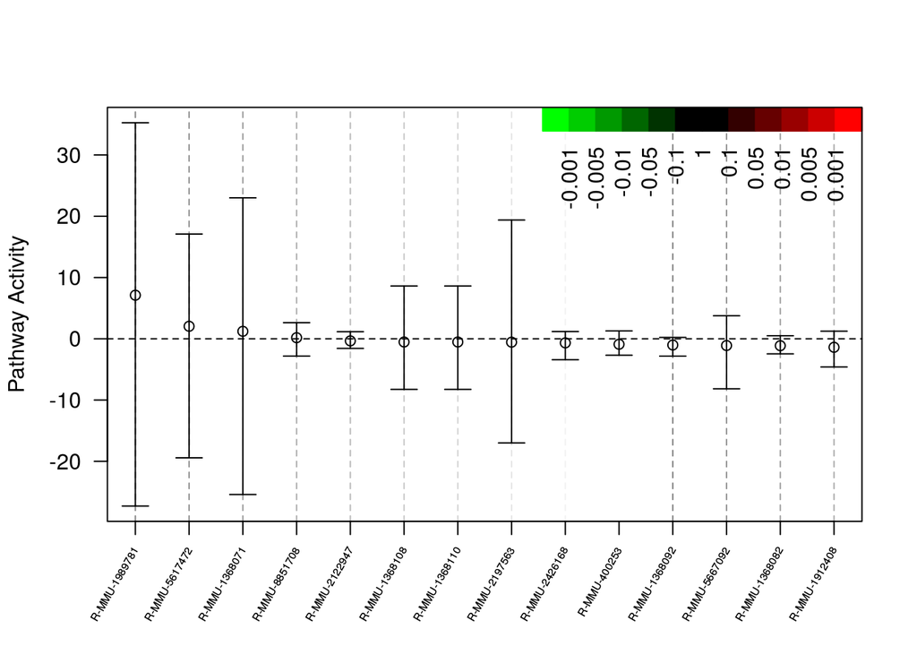

Full Enrichment Gene Analysis

|  | pathway.name | log.fold.change | p.Value | FDR | gn.Url | Pathway.Description |
| --- | --- | --- | --- | --- | --- | --- |
| 3 | R-MMU-1368092 | -1.0133576 | 0.0798973 | 0.7845091 | http://www.reactome.org/PathwayBrowser/#/R-MMU-1368092 | Rora activates gene expression |
| 2 | R-MMU-1368082 | -1.1243012 | 0.1595532 | 0.7845091 | http://www.reactome.org/PathwayBrowser/#/R-MMU-1368082 | RORA activates gene expression |
| 6 | R-MMU-1912408 | -1.3858843 | 0.1681091 | 0.7845091 | http://www.reactome.org/PathwayBrowser/#/R-MMU-1912408 | Pre-NOTCH Transcription and Translation |
| 10 | R-MMU-2426168 | -0.6651033 | 0.2283595 | 0.7992584 | http://www.reactome.org/PathwayBrowser/#/R-MMU-2426168 | Activation of gene expression by SREBF (SREBP) |
| 13 | R-MMU-5667092 | -1.0970427 | 0.3993486 | 0.9418414 | http://www.reactome.org/PathwayBrowser/#/R-MMU-5667092 | Nr1d1 (Rev-erba) represses gene expression |
| 11 | R-MMU-400253 | -0.8906632 | 0.4036463 | 0.9418414 | http://www.reactome.org/PathwayBrowser/#/R-MMU-400253 | Circadian Clock |
| 8 | R-MMU-2122947 | -0.3412004 | 0.7098422 | 0.9635735 | http://www.reactome.org/PathwayBrowser/#/R-MMU-2122947 | NOTCH1 Intracellular Domain Regulates Transcription |
| 7 | R-MMU-1989781 | 7.1152986 | 0.7223993 | 0.9635735 | http://www.reactome.org/PathwayBrowser/#/R-MMU-1989781 | PPARA activates gene expression |
| 9 | R-MMU-2197563 | -0.5496997 | 0.8713630 | 0.9635735 | http://www.reactome.org/PathwayBrowser/#/R-MMU-2197563 | NOTCH2 intracellular domain regulates transcription |
| 12 | R-MMU-5617472 | 2.0429872 | 0.8893354 | 0.9635735 | http://www.reactome.org/PathwayBrowser/#/R-MMU-5617472 | Activation of anterior HOX genes in hindbrain development during early embryogenesis |
| 1 | R-MMU-1368071 | 1.2216964 | 0.8917126 | 0.9635735 | http://www.reactome.org/PathwayBrowser/#/R-MMU-1368071 | NR1D1 (REV-ERBA) represses gene expression |
| 14 | R-MMU-8851708 | 0.1778461 | 0.9239526 | 0.9635735 | http://www.reactome.org/PathwayBrowser/#/R-MMU-8851708 | Signaling by FGFR2 IIIa TM |
| 4 | R-MMU-1368108 | -0.5223108 | 0.9635735 | 0.9635735 | http://www.reactome.org/PathwayBrowser/#/R-MMU-1368108 | BMAL1:CLOCK,NPAS2 activates circadian gene expression |
| 5 | R-MMU-1368110 | -0.5223108 | 0.9635735 | 0.9635735 | http://www.reactome.org/PathwayBrowser/#/R-MMU-1368110 | Bmal1:Clock,Npas2 activates circadian gene expression |

```
## [1] "the following geneSets with a p.value <0.1 have the following gene names in the set:"
```

```
## $`R-MMU-1368092`
## named list()
```

# 11 Settings

## 11.1 Detected Uploaded Fastas

```
## [1] "NOTINPUT"
```

## 11.2 Input Species

```
## [1] "Mus musculus"
```

## 11.3 Design Matrix

Two Group Design Matrix

|  | Intercept | CompVsControl |
| --- | --- | --- |
| WT-FI-2 | 1 | 1 |
| WT-FI-1 | 1 | 1 |
| WT-FI-4 | 1 | 1 |
| WT-FI-3 | 1 | 1 |
| WT-FI-5 | 1 | 1 |
| SIRT1mKO-FI-1 | 1 | 0 |
| SIRT1mKO-FI-2 | 1 | 0 |

## 11.4 RUV Weighted Variance

RUV Derived Weights

| W_1 |
| --- |
| -0.2272396 |
| -0.2567009 |
| 0.2754831 |
| -0.3749966 |
| 0.6040377 |
| -0.3981578 |
| 0.3775741 |

RUV Design Matrix

|  | (Intercept) | phenoDat$typeTrt | phenoDat$W_1 |
| --- | --- | --- | --- |
| WT-FI-2 | 1 | 1 | -0.2272396 |
| WT-FI-1 | 1 | 1 | -0.2567009 |
| WT-FI-4 | 1 | 1 | 0.2754831 |
| WT-FI-3 | 1 | 1 | -0.3749966 |
| WT-FI-5 | 1 | 1 | 0.6040377 |
| SIRT1mKO-FI-1 | 1 | 0 | -0.3981578 |
| SIRT1mKO-FI-2 | 1 | 0 | 0.3775741 |

## 11.5 AppSession Information

```
## $fastaUploads
## [1] "NOTINPUT"
##
## $comparisonSamples
## [1] "WT-FI-2" "WT-FI-1" "WT-FI-4" "WT-FI-3" "WT-FI-5"
##
## $controlSamples
## [1] "SIRT1mKO-FI-1" "SIRT1mKO-FI-2"
##
## $sampleDirPath
## [1] "/data/scratch/downloads/samples"
##
## $fastaPath
## [1] "/data/scratch/downloads/fastaUploads"
##
## $twa_outputPath
## [1] "/data/output/appresults/31291280/results//transcript-wise-Analysis"
##
## $gwa_outputPath
## [1] "/data/output/appresults/31291280/results//gene-wise-Analysis"
##
## $annotatedKexp_outputPath
## [1] "/data/output/appresults/31291280/results//AnnotatedKexp"
##
## $ercc_outputPath
## [1] "/data/output/appresults/31291280/results//ercc-Analysis"
##
## $enrich_outputPath
## [1] "/data/output/appresults/31291280/results//enrichment-Analysis"
```